# CNN_CIFAR (2)

### Fashion-MNIST with transfer learning

```python
from tensorflow.keras.applications import VGG16

#Calling VGG16 weights from Imagenet
conv_base = VGG16(weights='imagenet',
                  include_top=False,
                  input_shape=(56,56,3))

conv_base.summary()
```

```
Model: "vgg16"
_________________________________________________________________
Layer (type)                 Output Shape              Param #
=================================================================
input_14 (InputLayer)        [(None, 56, 56, 3)]       0
_________________________________________________________________
block1_conv1 (Conv2D)        (None, 56, 56, 64)        1792
_________________________________________________________________
block1_conv2 (Conv2D)        (None, 56, 56, 64)        36928
_________________________________________________________________
block1_pool (MaxPooling2D)   (None, 28, 28, 64)        0
_________________________________________________________________
block2_conv1 (Conv2D)        (None, 28, 28, 128)       73856
_________________________________________________________________
block2_conv2 (Conv2D)        (None, 28, 28, 128)       147584
_________________________________________________________________
block2_pool (MaxPooling2D)   (None, 14, 14, 128)       0
_________________________________________________________________
block3_conv1 (Conv2D)        (None, 14, 14, 256)       295168
_________________________________________________________________
block3_conv2 (Conv2D)        (None, 14, 14, 256)       590080
_________________________________________________________________
block3_conv3 (Conv2D)        (None, 14, 14, 256)       590080
_________________________________________________________________
block3_pool (MaxPooling2D)   (None, 7, 7, 256)         0
_________________________________________________________________
block4_conv1 (Conv2D)        (None, 7, 7, 512)         1180160
_________________________________________________________________
block4_conv2 (Conv2D)        (None, 7, 7, 512)         2359808
_________________________________________________________________
block4_conv3 (Conv2D)        (None, 7, 7, 512)         2359808
_________________________________________________________________
block4_pool (MaxPooling2D)   (None, 3, 3, 512)         0
_________________________________________________________________
block5_conv1 (Conv2D)        (None, 3, 3, 512)         2359808
_________________________________________________________________
block5_conv2 (Conv2D)        (None, 3, 3, 512)         2359808
_________________________________________________________________
block5_conv3 (Conv2D)        (None, 3, 3, 512)         2359808
_________________________________________________________________
block5_pool (MaxPooling2D)   (None, 1, 1, 512)         0
=================================================================
Total params: 14,714,688
Trainable params: 14,714,688
Non-trainable params: 0
_________________________________________________________________
```

```python
from tensorflow.keras import models
from tensorflow.keras import layers
from tensorflow.keras import optimizers

def transfer_model():
  new_model = models.Sequential()
  new_model.add(conv_base)
  new_model.add(layers.Flatten())
  new_model.add(layers.Dense(1024, activation = 'relu',kernel_regularizer=keras.regularizers.l2(0.0001)))
  new_model.add(layers.BatchNormalization())
  new_model.add(layers.Dropout(0.30))
  new_model.add(layers.Dense(512, activation = 'relu',kernel_regularizer=keras.regularizers.l2(0.0001)))
  new_model.add(layers.BatchNormalization())
  new_model.add(layers.Dropout(0.30))
  new_model.add(layers.Dense(10, activation='softmax'))

  return new_model

new_model = transfer_model()
new_model.summary()
```

```
Model: "sequential_24"
_________________________________________________________________
Layer (type)                 Output Shape              Param #
=================================================================
vgg16 (Model)                (None, 1, 1, 512)         14714688
_________________________________________________________________
flatten_22 (Flatten)         (None, 512)               0
_________________________________________________________________
dense_108 (Dense)            (None, 1024)              525312
_________________________________________________________________
batch_normalization_83 (Batc (None, 1024)              4096
_________________________________________________________________
dropout_87 (Dropout)         (None, 1024)              0
_________________________________________________________________
dense_109 (Dense)            (None, 512)               524800
_________________________________________________________________
batch_normalization_84 (Batc (None, 512)               2048
_________________________________________________________________
dropout_88 (Dropout)         (None, 512)               0
_________________________________________________________________
dense_110 (Dense)            (None, 10)                5130
=================================================================
Total params: 15,776,074
Trainable params: 15,773,002
Non-trainable params: 3,072
_________________________________________________________________
```

```python
train_datagen = ImageDataGenerator(
                rotation_range=40,
                width_shift_range=0.2,
                height_shift_range=0.2,
                shear_range=0.2,
                zoom_range=0.2,
                horizontal_flip=True,
                fill_mode='nearest')

val_datagen = ImageDataGenerator()

test_datagen = ImageDataGenerator()
batch_size = 64
```

```python
  # fit the data generator on training data & validate on
  num_train_batches = len(X_train_da) // batch_size
  #num_train_batches += (0 if len(X_train_new) % batch_size == 0 else 1)
  num_val_batches = len(X_val_da) // batch_size
  #num_val_batches += (0 if len(X_val_new) % batch_size == 0 else 1)
  num_test_batches = len(X_test_da) // batch_size
  #num_test_batches += (0 if len(X_test_new) % batch_size == 0 else 1)
```

```python
train_generator = train_datagen.flow(X_train_da, Y_train_da,
                                         batch_size=batch_size,
                                         shuffle=False)
val_generator = val_datagen.flow(X_val_da, Y_val_da,
                                         batch_size=batch_size)
test_generator = test_datagen.flow(X_test_da, den_test_labels,
                                       batch_size=batch_size)
```

```python
learning_rate = keras.callbacks.ReduceLROnPlateau(
    monitor='val_loss',
    factor=0.2,
    patience=2,
    verbose=1,
    mode='auto',
    min_delta=0.0001,
    cooldown=2,
    min_lr=0)

new_callback = [learning_rate]
```

```python
%%time
new_model = transfer_model()

new_model.compile(optimizer=optimizers.Adam(lr = 0.0001, beta_1=0.9, beta_2=0.999),
                loss='categorical_crossentropy',
                metrics=['accuracy'])

#Fitting model on training and validation dataset
history_new = new_model.fit_generator(train_generator,
                                      steps_per_epoch=num_train_batches,
                                      epochs = 50,
                                      validation_data=val_generator,
                                      validation_steps=num_val_batches,
                                      callbacks = [new_callback])
```

```
Epoch 00003: ReduceLROnPlateau reducing learning rate to 1.9999999494757503e-05.
Epoch 00009: ReduceLROnPlateau reducing learning rate to 3.999999898951501e-06.
Epoch 00021: ReduceLROnPlateau reducing learning rate to 7.999999979801942e-07.
Epoch 00024: ReduceLROnPlateau reducing learning rate to 1.600000018697756e-07.
Epoch 00031: ReduceLROnPlateau reducing learning rate to 3.199999980552093e-08.
Epoch 00034: ReduceLROnPlateau reducing learning rate to 6.399999818995639e-09.
Epoch 00037: ReduceLROnPlateau reducing learning rate to 1.279999928271991e-09.
Epoch 00040: ReduceLROnPlateau reducing learning rate to 2.55999976772614e-10.
Epoch 00045: ReduceLROnPlateau reducing learning rate to 5.119999424429978e-11.
Epoch 00048: ReduceLROnPlateau reducing learning rate to 1.0239999126415712e-11.
CPU times: user 52min 54s, sys: 6min 39s, total: 59min 33s
Wall time: 38min 48s
```

```
(0.0, 1.0)
```

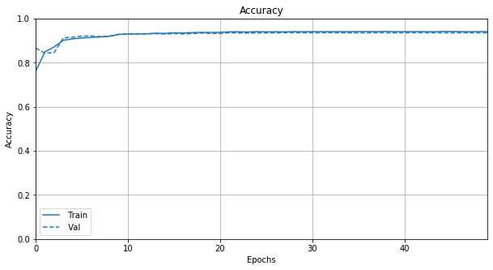

```python
#Plotting accuracy
plt.figure(figsize=(10,5))
plotter_accuracy = tfdocs.plots.HistoryPlotter()
plotter_accuracy.plot({"": history_new}, metric = "accuracy")
plt.title("Accuracy")
plt.ylim([0,1])
```

```
(0.0, 1.0)
```

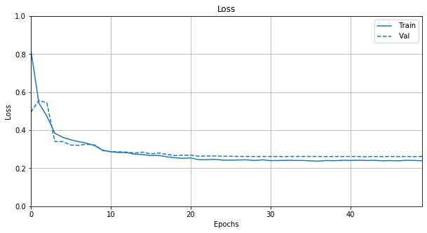

```python
#Plotting accuracy
plt.figure(figsize=(10,5))
plotter_accuracy = tfdocs.plots.HistoryPlotter()
plotter_accuracy.plot({"": history_new}, metric = "loss")
plt.title("Loss")
plt.ylim([0,1])
```

```python
#Augmented untuned conv2d model accuracy on test dataset
new_model_eval = new_model.evaluate(X_test_da, den_test_labels)
print("Loss on test dataset is {}\nAccuracy on test dataset is {}".format(round(new_model_eval[0],4),
round(new_model_eval[1],4)))
```

```
Loss on test dataset is 0.2667
Accuracy on test dataset is 0.9349
```

###### **Augmented model fine-tuned**

```python
#Calling VGG16 weights from Imagenet
conv_base = VGG16(weights='imagenet',
                  include_top=False,
                  input_shape=(56,56,3))

conv_base.summary()
```

```
Model: "vgg16"
_________________________________________________________________
Layer (type)                 Output Shape              Param #
=================================================================
input_16 (InputLayer)        [(None, 56, 56, 3)]       0
_________________________________________________________________
block1_conv1 (Conv2D)        (None, 56, 56, 64)        1792
_________________________________________________________________
block1_conv2 (Conv2D)        (None, 56, 56, 64)        36928
_________________________________________________________________
block1_pool (MaxPooling2D)   (None, 28, 28, 64)        0
_________________________________________________________________
block2_conv1 (Conv2D)        (None, 28, 28, 128)       73856
_________________________________________________________________
block2_conv2 (Conv2D)        (None, 28, 28, 128)       147584
_________________________________________________________________
block2_pool (MaxPooling2D)   (None, 14, 14, 128)       0
_________________________________________________________________
block3_conv1 (Conv2D)        (None, 14, 14, 256)       295168
_________________________________________________________________
block3_conv2 (Conv2D)        (None, 14, 14, 256)       590080
_________________________________________________________________
block3_conv3 (Conv2D)        (None, 14, 14, 256)       590080
_________________________________________________________________
block3_pool (MaxPooling2D)   (None, 7, 7, 256)         0
_________________________________________________________________
block4_conv1 (Conv2D)        (None, 7, 7, 512)         1180160
_________________________________________________________________
block4_conv2 (Conv2D)        (None, 7, 7, 512)         2359808
_________________________________________________________________
block4_conv3 (Conv2D)        (None, 7, 7, 512)         2359808
_________________________________________________________________
block4_pool (MaxPooling2D)   (None, 3, 3, 512)         0
_________________________________________________________________
block5_conv1 (Conv2D)        (None, 3, 3, 512)         2359808
_________________________________________________________________
block5_conv2 (Conv2D)        (None, 3, 3, 512)         2359808
_________________________________________________________________
block5_conv3 (Conv2D)        (None, 3, 3, 512)         2359808
_________________________________________________________________
block5_pool (MaxPooling2D)   (None, 1, 1, 512)         0
=================================================================
Total params: 14,714,688
Trainable params: 14,714,688
Non-trainable params: 0
_________________________________________________________________
```

```python
#Trainable till block 4 layers
conv_base.trainable = True
for layer in conv_base.layers[:15]:
   layer.trainable = True
for layer in conv_base.layers[15:]:
   layer.trainable = False
```

```python
conv_base.summary()
```

```
Model: "vgg16"
_________________________________________________________________
Layer (type)                 Output Shape              Param #
=================================================================
input_16 (InputLayer)        [(None, 56, 56, 3)]       0
_________________________________________________________________
block1_conv1 (Conv2D)        (None, 56, 56, 64)        1792
_________________________________________________________________
block1_conv2 (Conv2D)        (None, 56, 56, 64)        36928
_________________________________________________________________
block1_pool (MaxPooling2D)   (None, 28, 28, 64)        0
_________________________________________________________________
block2_conv1 (Conv2D)        (None, 28, 28, 128)       73856
_________________________________________________________________
block2_conv2 (Conv2D)        (None, 28, 28, 128)       147584
_________________________________________________________________
block2_pool (MaxPooling2D)   (None, 14, 14, 128)       0
_________________________________________________________________
block3_conv1 (Conv2D)        (None, 14, 14, 256)       295168
_________________________________________________________________
block3_conv2 (Conv2D)        (None, 14, 14, 256)       590080
_________________________________________________________________
block3_conv3 (Conv2D)        (None, 14, 14, 256)       590080
_________________________________________________________________
block3_pool (MaxPooling2D)   (None, 7, 7, 256)         0
_________________________________________________________________
block4_conv1 (Conv2D)        (None, 7, 7, 512)         1180160
_________________________________________________________________
block4_conv2 (Conv2D)        (None, 7, 7, 512)         2359808
_________________________________________________________________
block4_conv3 (Conv2D)        (None, 7, 7, 512)         2359808
_________________________________________________________________
block4_pool (MaxPooling2D)   (None, 3, 3, 512)         0
_________________________________________________________________
block5_conv1 (Conv2D)        (None, 3, 3, 512)         2359808
_________________________________________________________________
block5_conv2 (Conv2D)        (None, 3, 3, 512)         2359808
_________________________________________________________________
block5_conv3 (Conv2D)        (None, 3, 3, 512)         2359808
_________________________________________________________________
block5_pool (MaxPooling2D)   (None, 1, 1, 512)         0
=================================================================
Total params: 14,714,688
Trainable params: 7,635,264
Non-trainable params: 7,079,424
_________________________________________________________________
```

```python
def final_model():
  final_model = models.Sequential()
  final_model.add(conv_base)
  final_model.add(layers.Flatten())
  final_model.add(layers.Dense(1024, activation = 'relu'))
  final_model.add(layers.BatchNormalization())
  final_model.add(layers.Dense(512, activation = 'relu'))
  final_model.add(layers.BatchNormalization())
  final_model.add(layers.Dense(256, activation = 'relu'))
  final_model.add(layers.BatchNormalization())
  final_model.add(layers.Dense(10, activation='softmax'))

  return final_model

tuned_model = final_model()
tuned_model.summary()
```

```
Model: "sequential_45"
_________________________________________________________________
Layer (type)                 Output Shape              Param #
=================================================================
vgg16 (Model)                (None, 1, 1, 512)         14714688
_________________________________________________________________
flatten_43 (Flatten)         (None, 512)               0
_________________________________________________________________
dense_180 (Dense)            (None, 1024)              525312
_________________________________________________________________
batch_normalization_134 (Bat (None, 1024)              4096
_________________________________________________________________
dense_181 (Dense)            (None, 512)               524800
_________________________________________________________________
batch_normalization_135 (Bat (None, 512)               2048
_________________________________________________________________
dense_182 (Dense)            (None, 256)               131328
_________________________________________________________________
batch_normalization_136 (Bat (None, 256)               1024
_________________________________________________________________
dense_183 (Dense)            (None, 10)                2570
=================================================================
Total params: 15,905,866
Trainable params: 8,822,858
Non-trainable params: 7,083,008
_________________________________________________________________
```

```python
%%time

tuned_model = final_model()

tuned_model.compile(optimizer=optimizers.Adam(lr = 0.0001, beta_1=0.9, beta_2=0.999),
                loss='categorical_crossentropy',
                metrics=['accuracy'])

#Fitting model on training and validation dataset
tuned_model_history = tuned_model.fit_generator(train_generator,
                                      steps_per_epoch=num_train_batches,
                                      epochs = 50,
                                      validation_data=val_generator,
                                      validation_steps=num_val_batches,
                                      callbacks = [new_callback])
```

```
Epoch 00007: ReduceLROnPlateau reducing learning rate to 1.9999999494757503e-05.
Epoch 00016: ReduceLROnPlateau reducing learning rate to 3.999999898951501e-06.
Epoch 00021: ReduceLROnPlateau reducing learning rate to 7.999999979801942e-07.
Epoch 00025: ReduceLROnPlateau reducing learning rate to 1.600000018697756e-07.
Epoch 00030: ReduceLROnPlateau reducing learning rate to 3.199999980552093e-08.
Epoch 00033: ReduceLROnPlateau reducing learning rate to 6.399999818995639e-09.
Epoch 00036: ReduceLROnPlateau reducing learning rate to 1.279999928271991e-09.
Epoch 00039: ReduceLROnPlateau reducing learning rate to 2.55999976772614e-10.
Epoch 00042: ReduceLROnPlateau reducing learning rate to 5.119999424429978e-11.
Epoch 00045: ReduceLROnPlateau reducing learning rate to 1.0239999126415712e-11.
Epoch 00048: ReduceLROnPlateau reducing learning rate to 2.0479997905886727e-12.
CPU times: user 51min 49s, sys: 6min 11s, total: 58min 1s
Wall time: 38min 30s
```

```
(0.0, 1.0)
```

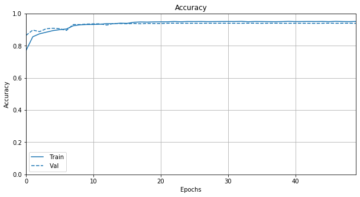

```python
#Plotting accuracy
plt.figure(figsize=(10,5))
plotter_accuracy = tfdocs.plots.HistoryPlotter()
plotter_accuracy.plot({"": tuned_model_history}, metric = "accuracy")
plt.title("Accuracy")
plt.ylim([0,1])
```

```
(0.0, 1.0)
```

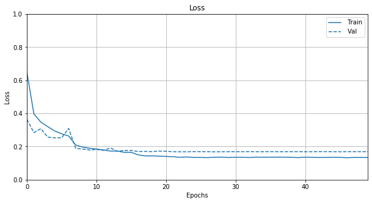

```python
#Plotting accuracy
plt.figure(figsize=(10,5))
plotter_accuracy = tfdocs.plots.HistoryPlotter()
plotter_accuracy.plot({"": tuned_model_history}, metric = "loss")
plt.title("Loss")
plt.ylim([0,1])
```

```python
#Augmented untuned conv2d model accuracy on test dataset
tuned_model_eval = tuned_model.evaluate(X_test_da, den_test_labels)
print("Loss on test dataset is {}\nAccuracy on test dataset is {}".format(round(tuned_model_eval[0],4),
round(tuned_model_eval[1],4)))
```

```
Loss on test dataset is 0.1844
Accuracy on test dataset is 0.9343
```

[figure not shown]

```python
#Comparing prediction with actual for first 10 records
predictions = tuned_model.predict(X_test_da)

plt.figure(figsize=(15, 15))
for i in range(20):
  pred = ("Prediction"+str(i)+":"+str(np.argmax(np.round(predictions[i]))))
  actual = ("Actual"+str(i)+":"+str(np.argmax(den_test_labels[i])))
  plt.subplot(5, 5, i+1)
  plt.subplots_adjust(wspace=0.5)
  plt.xticks([])
  plt.yticks([])
  plt.grid('off')
  plt.imshow(X_test_da[i])
  plt.title("Prediction Class {}\nOriginal Class {}".format(str(np.argmax(np.round(predictions[i]))),str(np.argmax(den_test_labels[i]))))
```

### Performance comparison

[figure not shown]

1) Increase in layers/size of the model might reduce accuracy and increase error rate (degradation problem). 2) VGG16 pre-trained weights are trained on image size of 224x224 wit RGB channel. Although, it can accept minimum 32x32 image size. But I guess, this model should work better on original color images instead of converted color images (conversion from 1 channel to 3 channels). 3) Due to increase in image size and channels, we need to add more layers which makes model time inefficient if its trained on CPU (less RAM). 4) VGG16 architecutre is too huge for fashion-mnist kind of data whcih results in overfitting. 5) I guess, data augmentation should work better on color images of living things instead of stalled things.

## CIFAR10

```python
import nvidia_smi
```

```python
#GPU model, number
!nvidia-smi -L
```

[output not shown]

```python
!lscpu
```

[output not shown]

```python
#GPU memory
nvidia_smi.nvmlInit()

handle = nvidia_smi.nvmlDeviceGetHandleByIndex(0)
info = nvidia_smi.nvmlDeviceGetMemoryInfo(handle)

print("Total memory:", info.total)
print("Free memory:", info.free)
print("Used memory:", info.used)

nvidia_smi.nvmlShutdown()
```

```
Total memory: 17071734784
Free memory: 17071734784
Used memory: 0
```

```python
#CPU information
!pip install py-cpuinfo
import cpuinfo
```

```
     |████████████████████████████████| 92kB 2.5MB/s
```

```python
print("CPU model is:",format(cpuinfo.get_cpu_info()['brand']))
print("CPU count is:", format(cpuinfo.get_cpu_info()['count']))
```

```
CPU model is: Intel(R) Xeon(R) CPU @ 2.20GHz
CPU count is: 4
```

```python
from keras.datasets import cifar10
(CIFAR_train_images, CIFAR_train_labels), (CIFAR_test_images, CIFAR_test_labels) = cifar10.load_data()
```

```
Downloading data from https://www.cs.toronto.edu/~kriz/cifar-10-python.tar.gz
```

```python
print("Train images shape: {}\nTrain labels shape: {}".format((CIFAR_train_images.shape), (CIFAR_train_labels.shape)))
print("Test images shape: {}\nTest labels shape: {}".format((CIFAR_test_images.shape), (CIFAR_test_labels.shape)))
```

```
Train images shape: (50000, 32, 32, 3)
Train labels shape: (50000, 1)
Test images shape: (10000, 32, 32, 3)
Test labels shape: (10000, 1)
```

```python
#Classes in CIFAR10
num_classes = 10
cifar10_classes = ["airplane", "automobile", "bird", "cat", "deer",
                   "dog", "frog", "horse", "ship", "truck"]
```

```python
#Preprocessing images
CIFAR_train_images = CIFAR_train_images.astype('float32')/255
CIFAR_test_images = CIFAR_test_images.astype('float32')/255

#Standardizing training and test images
CIFAR_train_images = (CIFAR_train_images-(CIFAR_train_images.mean()))/(CIFAR_train_images.std())
CIFAR_test_images = (CIFAR_test_images-(CIFAR_test_images.mean()))/(CIFAR_test_images.std())

#1-hot-coding for labels
CIFAR_train_label = to_categorical(CIFAR_train_labels)
CIFAR_test_label = to_categorical(CIFAR_test_labels)
```

```python
#Splitting training data into training and validation dataset
from sklearn.model_selection import train_test_split
X_train_CIFAR, X_val_CIFAR, Y_train_CIFAR, Y_val_CIFAR = train_test_split(CIFAR_train_images, CIFAR_train_label, test_size = 0.2, random_state = 1000)
```

```python
#Creating gGenerators
training_datagen = ImageDataGenerator()
validation_datagen = ImageDataGenerator()
testing_datagen = ImageDataGenerator()
batches_size = 64

train_batches = len(X_train_CIFAR) // batches_size
val_batches = len(X_val_CIFAR) // batches_size
test_batches = len(CIFAR_test_images) // batches_size


training_generator = training_datagen.flow(X_train_CIFAR, Y_train_CIFAR,
                                         batch_size=batches_size,
                                         shuffle=True)
validation_generator = validation_datagen.flow(X_val_CIFAR, Y_val_CIFAR,
                                         batch_size=batches_size)
testing_generator = testing_datagen.flow(CIFAR_test_images, CIFAR_test_label,
                                       batch_size=batches_size)
```

```python
#Model architecture
def base_model():
  cifar_base_model = models.Sequential()
  cifar_base_model.add(layers.Conv2D(filters=32, kernel_size=(3, 3), activation='relu', strides=1, padding='same',
                  kernel_initializer='he_uniform', input_shape=(32,32,3)))
  cifar_base_model.add(layers.Conv2D(filters=64, kernel_size=(3, 3), activation='relu', strides=1, padding='same',
                  kernel_initializer='he_uniform'))
  cifar_base_model.add(layers.MaxPooling2D(pool_size=(2, 2)))
  cifar_base_model.add(layers.Dropout(0.3))
  cifar_base_model.add(layers.Conv2D(filters=128, kernel_size=(3, 3), activation='relu', strides=1, padding='same',
                  kernel_initializer='he_uniform'))
  cifar_base_model.add(layers.MaxPooling2D(pool_size=(2, 2)))
  cifar_base_model.add(layers.Dropout(0.3))
  cifar_base_model.add(layers.Flatten())
  cifar_base_model.add(layers.Dense(256, activation='relu',kernel_regularizer=keras.regularizers.l2(0.0001)))
  cifar_base_model.add(layers.Dense(10, activation='softmax'))

  return cifar_base_model

cifar_base_model = base_model()
cifar_base_model.summary()
```

```
Model: "sequential"
_________________________________________________________________
Layer (type)                 Output Shape              Param #
=================================================================
conv2d (Conv2D)              (None, 32, 32, 32)        896
_________________________________________________________________
conv2d_1 (Conv2D)            (None, 32, 32, 64)        18496
_________________________________________________________________
max_pooling2d (MaxPooling2D) (None, 16, 16, 64)        0
_________________________________________________________________
dropout (Dropout)            (None, 16, 16, 64)        0
_________________________________________________________________
conv2d_2 (Conv2D)            (None, 16, 16, 128)       73856
_________________________________________________________________
max_pooling2d_1 (MaxPooling2 (None, 8, 8, 128)         0
_________________________________________________________________
dropout_1 (Dropout)          (None, 8, 8, 128)         0
_________________________________________________________________
flatten (Flatten)            (None, 8192)              0
_________________________________________________________________
dense (Dense)                (None, 256)               2097408
_________________________________________________________________
dense_1 (Dense)              (None, 10)                2570
=================================================================
Total params: 2,193,226
Trainable params: 2,193,226
Non-trainable params: 0
_________________________________________________________________
```

```python
#Compiling and fitting the model
%%time

cifar_base_model = base_model()

#Compiling model
cifar_base_model.compile(optimizer=optimizers.Adam(lr = 0.0001, beta_1=0.9, beta_2=0.999),
                loss='categorical_crossentropy',
                metrics=['accuracy'])

#Fitting model on training and validation dataset
hist_cifar_base_model = cifar_base_model.fit(training_generator,
                                      steps_per_epoch=train_batches,
                                      epochs = 100,
                                      validation_data=validation_generator,
                                      validation_steps=val_batches)
```

```
CPU times: user 7min 53s, sys: 1min 30s, total: 9min 24s
Wall time: 8min 5s
```

```
(0.0, 1.0)
```

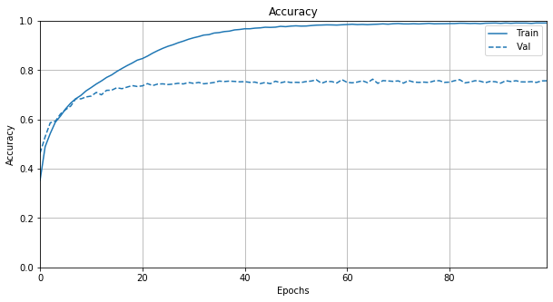

```python
#Plotting accuracy
plt.figure(figsize=(10,5))
plotter_accuracy = tfdocs.plots.HistoryPlotter()
plotter_accuracy.plot({"": hist_cifar_base_model}, metric = "accuracy")
plt.title("Accuracy")
plt.ylim([0,1])
```

```
(0.0, 2.0)
```

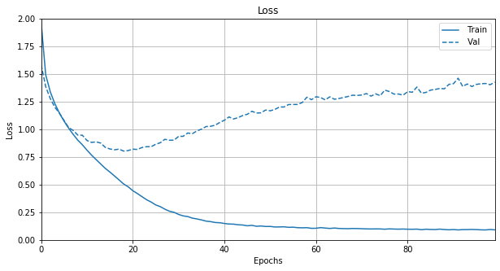

```python
#Plotting loss
plt.figure(figsize=(10,5))
plotter_accuracy = tfdocs.plots.HistoryPlotter()
plotter_accuracy.plot({"": hist_cifar_base_model}, metric = "loss")
plt.title("Loss")
plt.ylim([0,2])
```

```python
#Baseline CIFAR conv2d model accuracy on test dataset
cifar_base_model_eval = cifar_base_model.evaluate(CIFAR_test_images, CIFAR_test_label)
```

#### ResNet

```python
#Preprocessing images
resnet_train_images = CIFAR_train_images.astype('float32')/255
resnet_test_images = CIFAR_test_images.astype('float32')/255

#1-hot-coding for labels
resnet_train_labels = to_categorical(CIFAR_train_labels,num_classes)
resnet_test_labels = to_categorical(CIFAR_test_labels,num_classes)
```

```python
# Subtracting pixel mean improves accuracy
subtract_pixel_mean = True

# If subtract pixel mean is enabled
if subtract_pixel_mean:
    resnet_train_images_mean = np.mean(resnet_train_images, axis=0)
    resnet_train_images -= resnet_train_images_mean
    resnet_test_images -= resnet_train_images_mean

print("Train images shape: {}\nTrain labels shape: {}".format((resnet_train_images.shape), (resnet_train_labels.shape)))
print("Test images shape: {}\nTest labels shape: {}".format((resnet_test_images.shape), (resnet_test_labels.shape)))
```

```
Train images shape: (50000, 32, 32, 3)
Train labels shape: (50000, 10)
Test images shape: (10000, 32, 32, 3)
Test labels shape: (10000, 10)
```

```python
#Splitting training data into training and validation dataset
from sklearn.model_selection import train_test_split
X_train_resnet, X_val_resnet, Y_train_resnet, Y_val_resnet = train_test_split(resnet_train_images, resnet_train_labels, test_size = 0.2, random_state = 10000)
```

```python
from __future__ import print_function
import keras
from keras.layers import Dense, Conv2D, BatchNormalization, Activation
from keras.layers import AveragePooling2D, Input, Flatten
from keras.optimizers import Adam
from keras.callbacks import ModelCheckpoint, LearningRateScheduler
from keras.callbacks import ReduceLROnPlateau
from keras.preprocessing.image import ImageDataGenerator
from keras.regularizers import l2
from keras import backend as K
from keras.models import Model
from keras.datasets import cifar10
import numpy as np
import os
```

```python
#Creating generators

res_training_datagen = ImageDataGenerator(rotation_range=0,
    width_shift_range=0.1,
    zca_epsilon=1e-06,
    height_shift_range=0.1,
    shear_range=0.2,
    zoom_range=0.2,
    horizontal_flip=True,
    fill_mode='nearest')

res_training_no_aug = ImageDataGenerator()

res_validation_datagen = ImageDataGenerator()
res_testing_datagen = ImageDataGenerator()

# Training parameters
epochs = 200
num_classes = 10
res_batches_size = 32

res_train_batches = len(X_train_resnet) // res_batches_size
res_val_batches = len(X_val_resnet) // res_batches_size
res_test_batches = len(resnet_test_images) // res_batches_size
input_shape = X_train_resnet.shape[1:]

res_training_no_aug_generator = res_training_no_aug.flow(X_train_resnet, Y_train_resnet,
                                         batch_size=res_batches_size,
                                         shuffle=True)
res_training_generator = res_training_datagen.flow(X_train_resnet, Y_train_resnet,
                                         batch_size=res_batches_size,
                                         shuffle=True)
res_validation_generator = res_validation_datagen.flow(X_val_resnet, Y_val_resnet,
                                         batch_size=res_batches_size)
res_testing_generator = res_testing_datagen.flow(resnet_test_images, resnet_test_labels,
                                       batch_size=res_batches_size)
```

```python
#From keras.io
def lr_schedule(epoch):
    lr = 1e-3
    if epoch > 180:
        lr *= 0.5e-3
    elif epoch > 160:
        lr *= 1e-3
    elif epoch > 120:
        lr *= 1e-2
    elif epoch > 80:
        lr *= 1e-1
    return lr

lr_scheduler = LearningRateScheduler(lr_schedule)

lr_reducer = ReduceLROnPlateau(
    monitor='val_loss',
    factor=np.sqrt(0.1),
    patience=5,
    verbose=1,
    mode='auto',
    min_delta=0.0001,
    cooldown=0,
    min_lr=0.5e-6)


res_callback = [lr_reducer, lr_scheduler]
```

```python
def resnet_layer(inputs,
                 num_filters=16,
                 kernel_size=3,
                 strides=1,
                 activation='relu',
                 batch_normalization=True,
                 conv_first=True):

    conv = Conv2D(num_filters,
                  kernel_size=kernel_size,
                  strides=strides,
                  padding='same',
                  kernel_initializer='he_normal',
                  kernel_regularizer=l2(1e-4))

    x = inputs
    if conv_first:
        x = conv(x)
        if batch_normalization:
            x = BatchNormalization()(x)
        if activation is not None:
            x = Activation(activation)(x)
    else:
        if batch_normalization:
            x = BatchNormalization()(x)
        if activation is not None:
            x = Activation(activation)(x)
        x = conv(x)
    return x
```

```python
def resnet_v1(input_shape, depth, num_classes=10):


    # Start model definition.
    num_filters = 16
    num_res_blocks = int((depth - 2) / 6)

    inputs = Input(shape=input_shape)
    x = resnet_layer(inputs=inputs)
    # Instantiate the stack of residual units
    for stack in range(3):
        for res_block in range(num_res_blocks):
            strides = 1
            if stack > 0 and res_block == 0:  # first layer but not first stack
                strides = 2  # downsample
            y = resnet_layer(inputs=x,
                             num_filters=num_filters,
                             strides=strides)
            y = resnet_layer(inputs=y,
                             num_filters=num_filters,
                             activation=None)
            if stack > 0 and res_block == 0:  # first layer but not first stack
                # linear projection residual shortcut connection to match
                # changed dims
                x = resnet_layer(inputs=x,
                                 num_filters=num_filters,
                                 kernel_size=1,
                                 strides=strides,
                                 activation=None,
                                 batch_normalization=False)
            x = keras.layers.add([x, y])
            x = Activation('relu')(x)
        num_filters *= 2

    # Add classifier on top.
    # v1 does not use BN after last shortcut connection-ReLU
    x = AveragePooling2D(pool_size=8)(x)
    y = Flatten()(x)
    outputs = Dense(num_classes,
                    activation='softmax',
                    kernel_initializer='he_normal')(y)

    # Instantiate model.
    model = Model(inputs=inputs, outputs=outputs)
    return model
```

```python
res_model = resnet_v1(input_shape=X_train_CIFAR.shape[1:], depth=50)
res_model.summary()
```

```
Model: "model_1"
__________________________________________________________________________________________________
Layer (type)                    Output Shape         Param #     Connected to
==================================================================================================
input_1 (InputLayer)            (None, 32, 32, 3)    0
__________________________________________________________________________________________________
conv2d_1 (Conv2D)               (None, 32, 32, 16)   448         input_1[0][0]
__________________________________________________________________________________________________
batch_normalization_1 (BatchNor (None, 32, 32, 16)   64          conv2d_1[0][0]
__________________________________________________________________________________________________
activation_1 (Activation)       (None, 32, 32, 16)   0           batch_normalization_1[0][0]
__________________________________________________________________________________________________
conv2d_2 (Conv2D)               (None, 32, 32, 16)   2320        activation_1[0][0]
__________________________________________________________________________________________________
batch_normalization_2 (BatchNor (None, 32, 32, 16)   64          conv2d_2[0][0]
__________________________________________________________________________________________________
activation_2 (Activation)       (None, 32, 32, 16)   0           batch_normalization_2[0][0]
__________________________________________________________________________________________________
conv2d_3 (Conv2D)               (None, 32, 32, 16)   2320        activation_2[0][0]
__________________________________________________________________________________________________
batch_normalization_3 (BatchNor (None, 32, 32, 16)   64          conv2d_3[0][0]
__________________________________________________________________________________________________
add_1 (Add)                     (None, 32, 32, 16)   0           activation_1[0][0]
                                                                 batch_normalization_3[0][0]
__________________________________________________________________________________________________
activation_3 (Activation)       (None, 32, 32, 16)   0           add_1[0][0]
__________________________________________________________________________________________________
conv2d_4 (Conv2D)               (None, 32, 32, 16)   2320        activation_3[0][0]
__________________________________________________________________________________________________
batch_normalization_4 (BatchNor (None, 32, 32, 16)   64          conv2d_4[0][0]
__________________________________________________________________________________________________
activation_4 (Activation)       (None, 32, 32, 16)   0           batch_normalization_4[0][0]
__________________________________________________________________________________________________
conv2d_5 (Conv2D)               (None, 32, 32, 16)   2320        activation_4[0][0]
__________________________________________________________________________________________________
batch_normalization_5 (BatchNor (None, 32, 32, 16)   64          conv2d_5[0][0]
__________________________________________________________________________________________________
add_2 (Add)                     (None, 32, 32, 16)   0           activation_3[0][0]
                                                                 batch_normalization_5[0][0]
__________________________________________________________________________________________________
```

[output cut: 331 more lines]

```
add_24 (Add)                    (None, 8, 8, 64)     0           activation_47[0][0]
                                                                 batch_normalization_49[0][0]
__________________________________________________________________________________________________
activation_49 (Activation)      (None, 8, 8, 64)     0           add_24[0][0]
__________________________________________________________________________________________________
average_pooling2d_1 (AveragePoo (None, 1, 1, 64)     0           activation_49[0][0]
__________________________________________________________________________________________________
flatten_1 (Flatten)             (None, 64)           0           average_pooling2d_1[0][0]
__________________________________________________________________________________________________
dense_1 (Dense)                 (None, 10)           650         flatten_1[0][0]
==================================================================================================
Total params: 763,882
Trainable params: 760,266
Non-trainable params: 3,616
__________________________________________________________________________________________________
```

```python
%%time

res_model.compile(loss='categorical_crossentropy',
              optimizer=keras.optimizers.Adam(lr = 0.0001, beta_1=0.9, beta_2=0.999),
              metrics=['accuracy'])

history_res_model = res_model.fit_generator(
    res_training_generator,
    steps_per_epoch=res_train_batches,
    epochs=100,
    validation_data=res_validation_generator,
    validation_steps=res_val_batches,
    callbacks = [lr_reducer])
```

```
Epoch 00020: ReduceLROnPlateau reducing learning rate to 3.1622775802825264e-05.

Epoch 00028: ReduceLROnPlateau reducing learning rate to 9.999999259090306e-06.

Epoch 00038: ReduceLROnPlateau reducing learning rate to 3.162277292675049e-06.

Epoch 00043: ReduceLROnPlateau reducing learning rate to 9.999999115286567e-07.

Epoch 00048: ReduceLROnPlateau reducing learning rate to 5e-07.
CPU times: user 3h 43min 9s, sys: 21min 57s, total: 4h 5min 6s
Wall time: 2h 37min 52s
```

```
(0.0, 1.0)
```

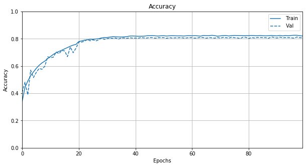

```python
#Plotting accuracy
plt.figure(figsize=(10,5))
plotter_accuracy = tfdocs.plots.HistoryPlotter()
plotter_accuracy.plot({"": history_res_model}, metric = "accuracy")
plt.title("Accuracy")
plt.ylim([0,1])
```

```
(0.0, 3.5)
```

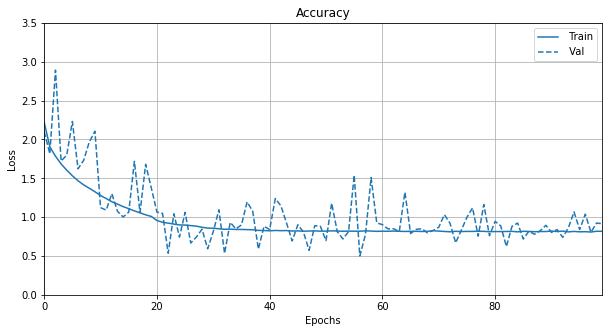

```python
#Plotting loss
plt.figure(figsize=(10,5))
plotter_accuracy = tfdocs.plots.HistoryPlotter()
plotter_accuracy.plot({"": history_res_model}, metric = "loss")
plt.title("Accuracy")
plt.ylim([0,3.5])
```

```python
#Baseline CIFAR conv2d model accuracy on test dataset
res_model_eval= res_model.evaluate(res_testing_generator)
print("Test accuracy: {}\n Test Loss: {}".format(round(res_model_eval[1],2),round(res_model_eval[0],2)))
```

```
Test accuracy: 0.8
 Test Loss: 0.93
```

**Resnet model without data agumentation**

```python
res_model_no_aug = resnet_v1(input_shape=X_train_CIFAR.shape[1:], depth=50)
res_model_no_aug.summary()
```

```
Model: "model_2"
__________________________________________________________________________________________________
Layer (type)                    Output Shape         Param #     Connected to
==================================================================================================
input_2 (InputLayer)            (None, 32, 32, 3)    0
__________________________________________________________________________________________________
conv2d_52 (Conv2D)              (None, 32, 32, 16)   448         input_2[0][0]
__________________________________________________________________________________________________
batch_normalization_50 (BatchNo (None, 32, 32, 16)   64          conv2d_52[0][0]
__________________________________________________________________________________________________
activation_50 (Activation)      (None, 32, 32, 16)   0           batch_normalization_50[0][0]
__________________________________________________________________________________________________
conv2d_53 (Conv2D)              (None, 32, 32, 16)   2320        activation_50[0][0]
__________________________________________________________________________________________________
batch_normalization_51 (BatchNo (None, 32, 32, 16)   64          conv2d_53[0][0]
__________________________________________________________________________________________________
activation_51 (Activation)      (None, 32, 32, 16)   0           batch_normalization_51[0][0]
__________________________________________________________________________________________________
conv2d_54 (Conv2D)              (None, 32, 32, 16)   2320        activation_51[0][0]
__________________________________________________________________________________________________
batch_normalization_52 (BatchNo (None, 32, 32, 16)   64          conv2d_54[0][0]
__________________________________________________________________________________________________
add_25 (Add)                    (None, 32, 32, 16)   0           activation_50[0][0]
                                                                 batch_normalization_52[0][0]
__________________________________________________________________________________________________
activation_52 (Activation)      (None, 32, 32, 16)   0           add_25[0][0]
__________________________________________________________________________________________________
conv2d_55 (Conv2D)              (None, 32, 32, 16)   2320        activation_52[0][0]
__________________________________________________________________________________________________
batch_normalization_53 (BatchNo (None, 32, 32, 16)   64          conv2d_55[0][0]
__________________________________________________________________________________________________
activation_53 (Activation)      (None, 32, 32, 16)   0           batch_normalization_53[0][0]
__________________________________________________________________________________________________
conv2d_56 (Conv2D)              (None, 32, 32, 16)   2320        activation_53[0][0]
__________________________________________________________________________________________________
batch_normalization_54 (BatchNo (None, 32, 32, 16)   64          conv2d_56[0][0]
__________________________________________________________________________________________________
add_26 (Add)                    (None, 32, 32, 16)   0           activation_52[0][0]
                                                                 batch_normalization_54[0][0]
__________________________________________________________________________________________________
```

[output cut: 331 more lines]

```
add_48 (Add)                    (None, 8, 8, 64)     0           activation_96[0][0]
                                                                 batch_normalization_98[0][0]
__________________________________________________________________________________________________
activation_98 (Activation)      (None, 8, 8, 64)     0           add_48[0][0]
__________________________________________________________________________________________________
average_pooling2d_2 (AveragePoo (None, 1, 1, 64)     0           activation_98[0][0]
__________________________________________________________________________________________________
flatten_2 (Flatten)             (None, 64)           0           average_pooling2d_2[0][0]
__________________________________________________________________________________________________
dense_2 (Dense)                 (None, 10)           650         flatten_2[0][0]
==================================================================================================
Total params: 763,882
Trainable params: 760,266
Non-trainable params: 3,616
__________________________________________________________________________________________________
```

```python
%%time

res_model_no_aug.compile(loss='categorical_crossentropy',
              optimizer=keras.optimizers.Adam(lr = 0.0001, beta_1=0.9, beta_2=0.999),
              metrics=['accuracy'])

history_res_model_no_aug = res_model_no_aug.fit_generator(
    res_training_no_aug_generator,
    steps_per_epoch=res_train_batches,
    epochs=100,
    validation_data=res_validation_generator,
    validation_steps=res_val_batches,
    callbacks = [lr_reducer])
```

```
Epoch 00011: ReduceLROnPlateau reducing learning rate to 3.1622775802825264e-05.

Epoch 00017: ReduceLROnPlateau reducing learning rate to 9.999999259090306e-06.

Epoch 00024: ReduceLROnPlateau reducing learning rate to 3.162277292675049e-06.

Epoch 00029: ReduceLROnPlateau reducing learning rate to 9.999999115286567e-07.

Epoch 00034: ReduceLROnPlateau reducing learning rate to 5e-07.
CPU times: user 5h 8min 55s, sys: 56min 53s, total: 6h 5min 49s
Wall time: 4h 44min 34s
```

```
(0.0, 1.0)
```

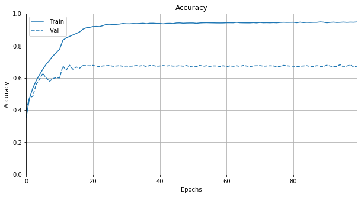

```python
#Plotting accuracy
plt.figure(figsize=(10,5))
plotter_accuracy = tfdocs.plots.HistoryPlotter()
plotter_accuracy.plot({"": history_res_model_no_aug}, metric = "accuracy")
plt.title("Accuracy")
plt.ylim([0,1])
```

```
(0.0, 3.5)
```

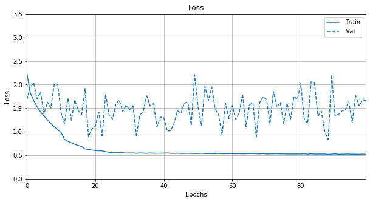

```python
#Plotting loss
plt.figure(figsize=(10,5))
plotter_accuracy = tfdocs.plots.HistoryPlotter()
plotter_accuracy.plot({"": history_res_model_no_aug}, metric = "loss")
plt.title("Loss")
plt.ylim([0,3.5])
```

```python
#Resnet no augmentation model accuracy on test dataset
res_model_no_aug_eval= res_model_no_aug.evaluate(res_testing_generator)
print("Test accuracy: {}\n Test Loss: {}".format(round(res_model_no_aug_eval[1],2),round(res_model_no_aug_eval[0],2)))
```

```
Test accuracy: 0.67
 Test Loss: 1.3
```

**Data augmentation provided better test accuracy and less overfit than without augmentation

**Option 1 - Learning rate schedule**

**2.2.1.1 Step Decay learning rate**

```python
#From Towards data science
def step_decay(epoch):
   initial_lrate = 0.001
   drop = 0.5
   epochs_drop = 5.0
   lrate = initial_lrate*tf.math.pow(drop,
           tf.math.floor((1+epoch)/epochs_drop))
   return float(lrate)

lr_decay=LearningRateScheduler(step_decay)

res_callback = [lr_decay]
```

```python
res_model_lr_decay = resnet_v1(input_shape=X_train_CIFAR.shape[1:], depth=50)
res_model_lr_decay.summary()
```

```
Model: "model_4"
__________________________________________________________________________________________________
Layer (type)                    Output Shape         Param #     Connected to
==================================================================================================
input_4 (InputLayer)            (None, 32, 32, 3)    0
__________________________________________________________________________________________________
conv2d_154 (Conv2D)             (None, 32, 32, 16)   448         input_4[0][0]
__________________________________________________________________________________________________
batch_normalization_148 (BatchN (None, 32, 32, 16)   64          conv2d_154[0][0]
__________________________________________________________________________________________________
activation_148 (Activation)     (None, 32, 32, 16)   0           batch_normalization_148[0][0]
__________________________________________________________________________________________________
conv2d_155 (Conv2D)             (None, 32, 32, 16)   2320        activation_148[0][0]
__________________________________________________________________________________________________
batch_normalization_149 (BatchN (None, 32, 32, 16)   64          conv2d_155[0][0]
__________________________________________________________________________________________________
activation_149 (Activation)     (None, 32, 32, 16)   0           batch_normalization_149[0][0]
__________________________________________________________________________________________________
conv2d_156 (Conv2D)             (None, 32, 32, 16)   2320        activation_149[0][0]
__________________________________________________________________________________________________
batch_normalization_150 (BatchN (None, 32, 32, 16)   64          conv2d_156[0][0]
__________________________________________________________________________________________________
add_73 (Add)                    (None, 32, 32, 16)   0           activation_148[0][0]
                                                                 batch_normalization_150[0][0]
__________________________________________________________________________________________________
activation_150 (Activation)     (None, 32, 32, 16)   0           add_73[0][0]
__________________________________________________________________________________________________
conv2d_157 (Conv2D)             (None, 32, 32, 16)   2320        activation_150[0][0]
__________________________________________________________________________________________________
batch_normalization_151 (BatchN (None, 32, 32, 16)   64          conv2d_157[0][0]
__________________________________________________________________________________________________
activation_151 (Activation)     (None, 32, 32, 16)   0           batch_normalization_151[0][0]
__________________________________________________________________________________________________
conv2d_158 (Conv2D)             (None, 32, 32, 16)   2320        activation_151[0][0]
__________________________________________________________________________________________________
batch_normalization_152 (BatchN (None, 32, 32, 16)   64          conv2d_158[0][0]
__________________________________________________________________________________________________
add_74 (Add)                    (None, 32, 32, 16)   0           activation_150[0][0]
                                                                 batch_normalization_152[0][0]
__________________________________________________________________________________________________
```

[output cut: 331 more lines]

```
add_96 (Add)                    (None, 8, 8, 64)     0           activation_194[0][0]
                                                                 batch_normalization_196[0][0]
__________________________________________________________________________________________________
activation_196 (Activation)     (None, 8, 8, 64)     0           add_96[0][0]
__________________________________________________________________________________________________
average_pooling2d_4 (AveragePoo (None, 1, 1, 64)     0           activation_196[0][0]
__________________________________________________________________________________________________
flatten_4 (Flatten)             (None, 64)           0           average_pooling2d_4[0][0]
__________________________________________________________________________________________________
dense_4 (Dense)                 (None, 10)           650         flatten_4[0][0]
==================================================================================================
Total params: 763,882
Trainable params: 760,266
Non-trainable params: 3,616
__________________________________________________________________________________________________
```

```python
%%time

res_model_lr_decay.compile(loss='categorical_crossentropy',
              optimizer=keras.optimizers.Adam(lr = 0.001, beta_1=0.9, beta_2=0.999),
              metrics=['accuracy'])

history_res_model_lr_decay = res_model_lr_decay.fit_generator(
    res_training_generator,
    steps_per_epoch=res_train_batches,
    epochs=50,
    validation_data=res_validation_generator,
    validation_steps=res_val_batches,
    callbacks = res_callback)
```

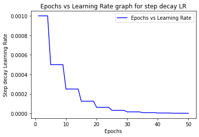

```python
lr = history_res_model_lr_decay.history["lr"]
epochs = range(1, len(lr) + 1)

plt.plot(epochs, lr, color="blue", label="Epochs vs Learning Rate")
plt.xlabel('Epochs')
plt.ylabel('Step decay Learning Rate')
plt.title("Epochs vs Learning Rate graph for step decay LR")
plt.legend()
plt.show()
```

```
(0.0, 1.0)
```

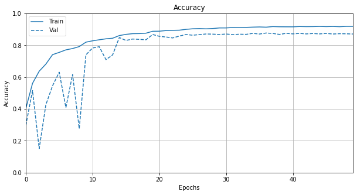

```python
#Plotting accuracy
plt.figure(figsize=(10,5))
plotter_accuracy = tfdocs.plots.HistoryPlotter()
plotter_accuracy.plot({"": history_res_model_lr_decay}, metric = "accuracy")
plt.title("Accuracy")
plt.ylim([0,1])
```

```
(0.0, 3.5)
```

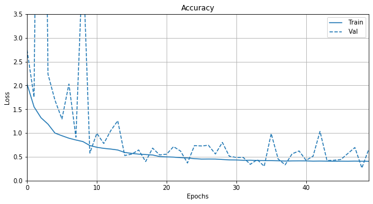

```python
#Plotting loss
plt.figure(figsize=(10,5))
plotter_accuracy = tfdocs.plots.HistoryPlotter()
plotter_accuracy.plot({"": history_res_model_lr_decay}, metric = "loss")
plt.title("Accuracy")
plt.ylim([0,3.5])
```

```python
#Resnet step decay LR model accuracy on test dataset
res_model_lr_decay_eval = res_model_lr_decay.evaluate(res_testing_generator)
print("Test accuracy: {}\n Test Loss: {}".format(round(res_model_lr_decay_eval[1],2),round(res_model_lr_decay_eval[0],2)))
```

```
Test accuracy: 0.86
 Test Loss: 0.38
```

**Step decay takes three hyperparameters, drop parameter defines percentage drop in lr, epochs_drop defines interval of epochs for such drop, and lastly intial lr. Setting drop to 0.5 constant, model was fine tuned using intial rate to 0.001 and epoch_drop to 5. To tal number of epochs i.e. 50 and general trial performance was considered to set these hyperparametes.**

**2.2.1.2 Cyclical learning rate**

```python
#From kaggle
from keras.callbacks import Callback
class CyclicLR(Callback):
    def __init__(
            self,base_lr=0.0001,
            max_lr=0.0006,step_size=2000.,
            mode='triangular',gamma=1.,
            scale_fn=None,scale_mode='cycle'):

        super(CyclicLR, self).__init__()

        if mode not in ['triangular', 'triangular2','exp_range']:
            raise KeyError("mode must be one of 'triangular', "
                           "'triangular2', or 'exp_range'")
        self.base_lr = base_lr
        self.max_lr = max_lr
        self.step_size = step_size
        self.mode = mode
        self.gamma = gamma
        if scale_fn is None:
            if self.mode == 'triangular':
                self.scale_fn = lambda x: 1.
                self.scale_mode = 'cycle'
            elif self.mode == 'triangular2':
                self.scale_fn = lambda x: 1 / (2.**(x - 1))
                self.scale_mode = 'cycle'
            elif self.mode == 'exp_range':
                self.scale_fn = lambda x: gamma ** x
                self.scale_mode = 'iterations'
        else:
            self.scale_fn = scale_fn
            self.scale_mode = scale_mode
        self.clr_iterations = 0.
        self.trn_iterations = 0.
        self.history = {}

        self._reset()

    def _reset(self, new_base_lr=None, new_max_lr=None,
               new_step_size=None):
        if new_base_lr is not None:
            self.base_lr = new_base_lr
        if new_max_lr is not None:
            self.max_lr = new_max_lr
        if new_step_size is not None:
            self.step_size = new_step_size
        self.clr_iterations = 0.

    def clr(self):
        cycle = np.floor(1 + self.clr_iterations / (2 * self.step_size))
        x = np.abs(self.clr_iterations / self.step_size - 2 * cycle + 1)
        if self.scale_mode == 'cycle':
            return self.base_lr + (self.max_lr - self.base_lr) * \
                np.maximum(0, (1 - x)) * self.scale_fn(cycle)
        else:
            return self.base_lr + (self.max_lr - self.base_lr) * \
                np.maximum(0, (1 - x)) * self.scale_fn(self.clr_iterations)

    def on_train_begin(self, logs={}):
        logs = logs or {}

        if self.clr_iterations == 0:
            K.set_value(self.model.optimizer.lr, self.base_lr)
        else:
            K.set_value(self.model.optimizer.lr, self.clr())

    def on_batch_end(self, epoch, logs=None):

        logs = logs or {}
        self.trn_iterations += 1
        self.clr_iterations += 1
        K.set_value(self.model.optimizer.lr, self.clr())

        self.history.setdefault(
            'lr', []).append(
            K.get_value(
                self.model.optimizer.lr))
        self.history.setdefault('iterations', []).append(self.trn_iterations)

        for k, v in logs.items():
            self.history.setdefault(k, []).append(v)

    def on_epoch_end(self, epoch, logs=None):
        logs = logs or {}
        logs['lr'] = K.get_value(self.model.optimizer.lr)
```

```python
#From pyimagesearch.com
lr_cycle = CyclicLR(mode="triangular",base_lr=0.0001, max_lr=0.0006,
                        step_size=2000.)
```

```python
res_model_lr_cycle = resnet_v1(input_shape=X_train_CIFAR.shape[1:], depth=50)
res_model_lr_cycle.summary()
```

```
Model: "model_3"
__________________________________________________________________________________________________
Layer (type)                    Output Shape         Param #     Connected to
==================================================================================================
input_3 (InputLayer)            (None, 32, 32, 3)    0
__________________________________________________________________________________________________
conv2d_103 (Conv2D)             (None, 32, 32, 16)   448         input_3[0][0]
__________________________________________________________________________________________________
batch_normalization_99 (BatchNo (None, 32, 32, 16)   64          conv2d_103[0][0]
__________________________________________________________________________________________________
activation_99 (Activation)      (None, 32, 32, 16)   0           batch_normalization_99[0][0]
__________________________________________________________________________________________________
conv2d_104 (Conv2D)             (None, 32, 32, 16)   2320        activation_99[0][0]
__________________________________________________________________________________________________
batch_normalization_100 (BatchN (None, 32, 32, 16)   64          conv2d_104[0][0]
__________________________________________________________________________________________________
activation_100 (Activation)     (None, 32, 32, 16)   0           batch_normalization_100[0][0]
__________________________________________________________________________________________________
conv2d_105 (Conv2D)             (None, 32, 32, 16)   2320        activation_100[0][0]
__________________________________________________________________________________________________
batch_normalization_101 (BatchN (None, 32, 32, 16)   64          conv2d_105[0][0]
__________________________________________________________________________________________________
add_49 (Add)                    (None, 32, 32, 16)   0           activation_99[0][0]
                                                                 batch_normalization_101[0][0]
__________________________________________________________________________________________________
activation_101 (Activation)     (None, 32, 32, 16)   0           add_49[0][0]
__________________________________________________________________________________________________
conv2d_106 (Conv2D)             (None, 32, 32, 16)   2320        activation_101[0][0]
__________________________________________________________________________________________________
batch_normalization_102 (BatchN (None, 32, 32, 16)   64          conv2d_106[0][0]
__________________________________________________________________________________________________
activation_102 (Activation)     (None, 32, 32, 16)   0           batch_normalization_102[0][0]
__________________________________________________________________________________________________
conv2d_107 (Conv2D)             (None, 32, 32, 16)   2320        activation_102[0][0]
__________________________________________________________________________________________________
batch_normalization_103 (BatchN (None, 32, 32, 16)   64          conv2d_107[0][0]
__________________________________________________________________________________________________
add_50 (Add)                    (None, 32, 32, 16)   0           activation_101[0][0]
                                                                 batch_normalization_103[0][0]
__________________________________________________________________________________________________
```

[output cut: 331 more lines]

```
add_72 (Add)                    (None, 8, 8, 64)     0           activation_145[0][0]
                                                                 batch_normalization_147[0][0]
__________________________________________________________________________________________________
activation_147 (Activation)     (None, 8, 8, 64)     0           add_72[0][0]
__________________________________________________________________________________________________
average_pooling2d_3 (AveragePoo (None, 1, 1, 64)     0           activation_147[0][0]
__________________________________________________________________________________________________
flatten_3 (Flatten)             (None, 64)           0           average_pooling2d_3[0][0]
__________________________________________________________________________________________________
dense_3 (Dense)                 (None, 10)           650         flatten_3[0][0]
==================================================================================================
Total params: 763,882
Trainable params: 760,266
Non-trainable params: 3,616
__________________________________________________________________________________________________
```

```python
%%time

res_model_lr_cycle.compile(loss='categorical_crossentropy',
              optimizer=keras.optimizers.Adam(lr = 0.0001, beta_1=0.9, beta_2=0.999),
              metrics=['accuracy'])

history_res_model_lr_cycle = res_model_lr_cycle.fit_generator(
    res_training_generator,
    steps_per_epoch=res_train_batches,
    epochs=100,
    validation_data=res_validation_generator,
    validation_steps=res_val_batches,
    callbacks = [lr_cycle])
```

```
CPU times: user 5h 58min 33s, sys: 56min 50s, total: 6h 55min 23s
Wall time: 4h 50min 49s
```

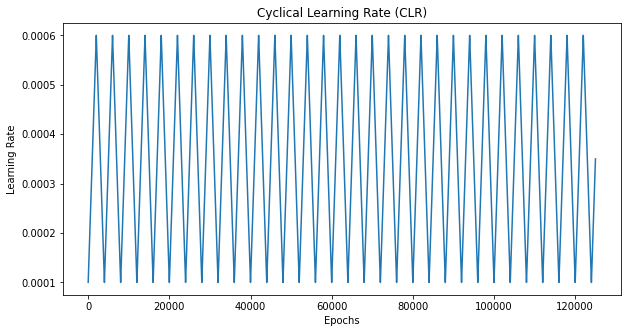

```python
# plot the learning rate history
N = np.arange(0, len(lr_cycle.history["lr"]))
plt.figure(figsize=(10,5))
plt.plot(N, lr_cycle.history["lr"])
plt.title("Cyclical Learning Rate (CLR)")
plt.xlabel("Epochs")
plt.ylabel("Learning Rate")
```

```
(0.0, 1.0)
```

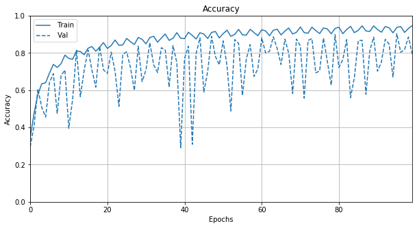

```python
#Plotting accuracy
plt.figure(figsize=(10,5))
plotter_accuracy = tfdocs.plots.HistoryPlotter()
plotter_accuracy.plot({"": history_res_model_lr_cycle}, metric = "accuracy")
plt.title("Accuracy")
plt.ylim([0,1])
```

```
(0.0, 5.0)
```

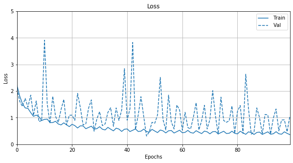

```python
#Plotting Loss
ylim=round(max(history_res_model_lr_cycle.history['val_loss']),0)+1
plt.figure(figsize=(10,5))
plotter_accuracy = tfdocs.plots.HistoryPlotter()
plotter_accuracy.plot({"": history_res_model_lr_cycle}, metric = "loss")
plt.title("Loss")
plt.ylim([0,ylim])
```

```python
#Resnet cyclic  LR model accuracy on test dataset
res_model_lr_cycle_eval = res_model_lr_cycle.evaluate(res_testing_generator)
print("Test accuracy: {}\n Test Loss: {}".format(round(res_model_lr_cycle_eval[1],2),round(res_model_lr_cycle_eval[0],2)))
```

```
Test accuracy: 0.79
 Test Loss: 1.51
```

**2.2.1.3 Exponential decay learning rate**

```python
#Defining exponential decay (towardsdatascience.com)
def exp_decay(epoch):
   intial_lr = 0.001
   d = 0.1
   lr = intial_lr*np.exp(-d*epoch)
   return lr

exp_decay=LearningRateScheduler(exp_decay)

res_callback = [exp_decay]
```

```python
res_model_exp_cycle = resnet_v1(input_shape=X_train_CIFAR.shape[1:], depth=50)
res_model_exp_cycle.summary()
```

```
Model: "model_5"
__________________________________________________________________________________________________
Layer (type)                    Output Shape         Param #     Connected to
==================================================================================================
input_5 (InputLayer)            (None, 32, 32, 3)    0
__________________________________________________________________________________________________
conv2d_205 (Conv2D)             (None, 32, 32, 16)   448         input_5[0][0]
__________________________________________________________________________________________________
batch_normalization_197 (BatchN (None, 32, 32, 16)   64          conv2d_205[0][0]
__________________________________________________________________________________________________
activation_197 (Activation)     (None, 32, 32, 16)   0           batch_normalization_197[0][0]
__________________________________________________________________________________________________
conv2d_206 (Conv2D)             (None, 32, 32, 16)   2320        activation_197[0][0]
__________________________________________________________________________________________________
batch_normalization_198 (BatchN (None, 32, 32, 16)   64          conv2d_206[0][0]
__________________________________________________________________________________________________
activation_198 (Activation)     (None, 32, 32, 16)   0           batch_normalization_198[0][0]
__________________________________________________________________________________________________
conv2d_207 (Conv2D)             (None, 32, 32, 16)   2320        activation_198[0][0]
__________________________________________________________________________________________________
batch_normalization_199 (BatchN (None, 32, 32, 16)   64          conv2d_207[0][0]
__________________________________________________________________________________________________
add_97 (Add)                    (None, 32, 32, 16)   0           activation_197[0][0]
                                                                 batch_normalization_199[0][0]
__________________________________________________________________________________________________
activation_199 (Activation)     (None, 32, 32, 16)   0           add_97[0][0]
__________________________________________________________________________________________________
conv2d_208 (Conv2D)             (None, 32, 32, 16)   2320        activation_199[0][0]
__________________________________________________________________________________________________
batch_normalization_200 (BatchN (None, 32, 32, 16)   64          conv2d_208[0][0]
__________________________________________________________________________________________________
activation_200 (Activation)     (None, 32, 32, 16)   0           batch_normalization_200[0][0]
__________________________________________________________________________________________________
conv2d_209 (Conv2D)             (None, 32, 32, 16)   2320        activation_200[0][0]
__________________________________________________________________________________________________
batch_normalization_201 (BatchN (None, 32, 32, 16)   64          conv2d_209[0][0]
__________________________________________________________________________________________________
add_98 (Add)                    (None, 32, 32, 16)   0           activation_199[0][0]
                                                                 batch_normalization_201[0][0]
__________________________________________________________________________________________________
```

[output cut: 331 more lines]

```
add_120 (Add)                   (None, 8, 8, 64)     0           activation_243[0][0]
                                                                 batch_normalization_245[0][0]
__________________________________________________________________________________________________
activation_245 (Activation)     (None, 8, 8, 64)     0           add_120[0][0]
__________________________________________________________________________________________________
average_pooling2d_5 (AveragePoo (None, 1, 1, 64)     0           activation_245[0][0]
__________________________________________________________________________________________________
flatten_5 (Flatten)             (None, 64)           0           average_pooling2d_5[0][0]
__________________________________________________________________________________________________
dense_5 (Dense)                 (None, 10)           650         flatten_5[0][0]
==================================================================================================
Total params: 763,882
Trainable params: 760,266
Non-trainable params: 3,616
__________________________________________________________________________________________________
```

```python
%%time

res_model_exp_cycle.compile(loss='categorical_crossentropy',
              optimizer=keras.optimizers.Adam(lr = 0.0001, beta_1=0.9, beta_2=0.999),
              metrics=['accuracy'])

history_res_model_exp_cycle = res_model_exp_cycle.fit_generator(
    res_training_generator,
    steps_per_epoch=res_train_batches,
    epochs=30,
    validation_data=res_validation_generator,
    validation_steps=res_val_batches,
    callbacks = [exp_decay])
```

```
CPU times: user 1h 48min 53s, sys: 16min 59s, total: 2h 5min 53s
Wall time: 1h 27min 23s
```

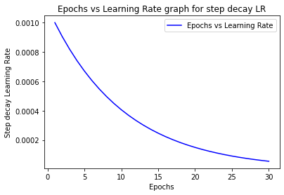

```python
# plot the learning rate history
lr = history_res_model_exp_cycle.history["lr"]
epochs = range(1, len(lr) + 1)

plt.plot(epochs, lr, color="blue", label="Epochs vs Learning Rate")
plt.xlabel('Epochs')
plt.ylabel('Step decay Learning Rate')
plt.title("Epochs vs Learning Rate graph for step decay LR")
plt.legend()
plt.show()
```

```
(0.0, 1.0)
```

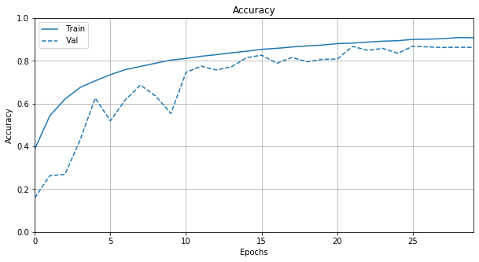

```python
#Plotting accuracy
plt.figure(figsize=(10,5))
plotter_accuracy = tfdocs.plots.HistoryPlotter()
plotter_accuracy.plot({"": history_res_model_exp_cycle}, metric = "accuracy")
plt.title("Accuracy")
plt.ylim([0,1])
```

```
(0.0, 5.0)
```

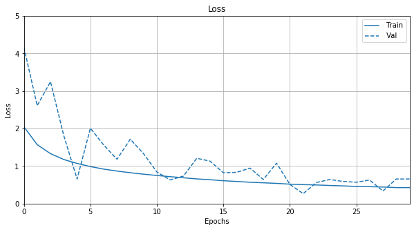

```python
#Plotting loss
plt.figure(figsize=(10,5))
plotter_accuracy = tfdocs.plots.HistoryPlotter()
plotter_accuracy.plot({"": history_res_model_exp_cycle}, metric = "loss")
plt.title("Loss")
plt.ylim([0,5])
```

```python
#Resnet Exp decay LR model accuracy on test dataset
res_model_exp_cycle.evaluate(res_testing_generator)
```

```
[0.3574821949005127, 0.8536999821662903]
```

**Exponential decay has the mathematical form of lr=intial_lr *exp(-k*epoch). Initial learning rate hyperparameter is used based on knowledge gained from previous models, k and epochs defines the steps for exponential.**

### Performance comparison

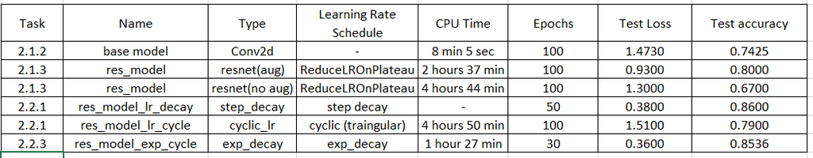

**Due to time constraint and constantly running out of GPU, I could run only 50 epochs for steps decay lr and 30 epochs for expoential decay. However, steps decay model got converged after 30 epochs based on training loss/accuracy. Thus, it is still considered comparable with other models with 100 epochs. Best model is with steps decay which provided 0.38 loss and 0.86 accuracy on test data. Also, it was comparatively time efficient. Base model is quick, but it suffers from severe overfit and validation loss shoots up after 20 epochs. As mentioned earlier, data augmentation provided better fit on original RGB image rather than converted RGB image as we did for VGG16 fashion-mnist. Step decay performs well may because gradient descent of loss takes bigger steps earlier towards minima and takes smaller steps once near minima. This helps model to find more deeper loss space. Cyclic lr also performs better, but due to its cyclic nature, it impacts test loss tends to be higher. However, other variants of decaying cyclic rates are worth trying. My favorite hyperparameter is learning rate, because it gives me indirect access to adjust the gradient which affects the weights and accuracy. Also, I would like to understand why sometimes loss and accuracy move is same direction whereas logically it should inverse relationship. I have observed that while evaluating model on test data, test loss is different for test data given in mini batches and entire test dataset. Please suggest which method is technically and ethically correct. I have kept test data in batches to be in consistent with training and validation data.**

##### **References**

> kaggle.com

> towardsdatascience.com

> keras.io

> pyimagesearch.com

> stackoverflow.com

```python
jupyter nbconvert --to html notebook.ipynb
```